# Analyzing Female Representation in Hollywood Movies Using the Bechdel Test

Madeleine Hickman, Christian Madrigal, Nukhbah Majid, Annabel Shein

12/15/2019

```r
bechdelSampleNEW  <- read_csv(file = "bechdelSampleNEW.csv")
```

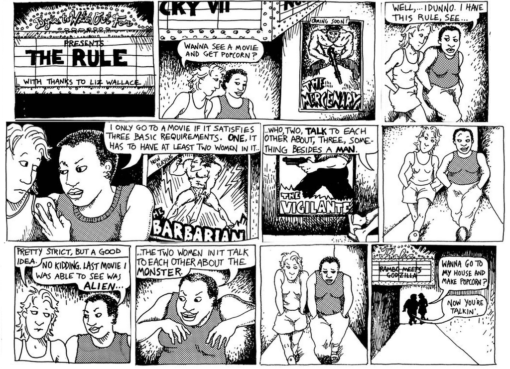

*The Bechdel Test comic strip*

# Abstract

Our project was a detailed analysis of female representation in Hollywood movies using the Bechdel Test. The Bechdel Test is an assessment that evaluates whether a film portrays women in a way that is biased. The following requirements need to be met in order to pass the Bechdel Test: (i) A work must feature at least two named women, (ii) Who talk to each other, and (iii) Their conversation subject must not be a man. We carried out multiple statistical tests to analyze different patterns in the data. These are the tests that we carried out: (a) Test for a difference in means of international gross of movies that passed the Bechdel Test vs. international gross of movies that did not pass the Bechdel Test (b) Test for a difference in proportions of movies that passed the Bechdel Test directed by females and movies that passed the Bechdel Test directed by males, and (c) Testing for predicted international gross using Multiple Regression analysis based on the following factors: (i) Pass (whether the movie passed the Bechdel Test or not), (ii) Budget, (iii) IMDb score. Generalizing to the fivethirtyeight sample from which we collected our data, our model suggests that passing the Bechdel Test is a significant predictor for the international success of a movie. We are hesitant to generalize to all movies that were produced between 1990 and 2013 given that the data was not, in actuality, collected randomly, because the fivethirtyeight[^1] data was taken from two datasets, one of which was crowdsourced, and the other of which we do not know their data-collection method . Overall, our model would not be used in real-world applications as the necessary conditions were not met, but for the purpose of this project we can make conclusions without implying causality.

The generalizations from our analyses are explained in depth below.

# Introduction

Our project analyzes a subset of Hollywood movies (200 random cases) to assess trends relating to the Bechdel Test, which is a way of evaluating whether a film portrays women in a way that is biased or characterized by gender stereotyping. To pass the Bechdel test, a work must feature at least two named women, these women must talk to each other, and their conversation must concern something other than a man. The goal of this project was to analyze whether passing the Bechdel test was a significant factor in a movie’s success.

# Methods

## ANALYSIS ONE

### Question: What does the mean budget in 2013 United States Dollars (USD) look like for the movies in the sample at a 95% confidence level?

### Assumptions:

To construct a confidence interval, we assumed that the data collected by fivethirtyeight was randomly sampled. Given that we randomly sampled 200 cases from the original sample provided from the original fivethirtyeight sample, we are sure that the confidence interval that we constructed is appropriate.

### Data visualization

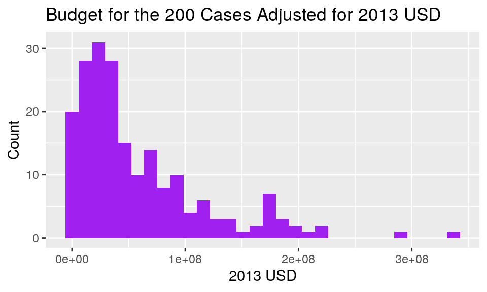

```r
ggplot(data = bechdelSampleNEW, aes(x = budget_2013))+
  geom_histogram(fill="purple") + labs(x="2013 USD", y="Count", title="Budget for the 200 Cases Adjusted for 2013 USD")
```

### Summary statistics

Prior to constructing a 95% confidence interval with the bootstrap distribution we found some summary statistics of our random sample of 200 cases. It was demonstrated that the mean budget for the 200 cases was 58.8 million USD adjusted for inflation in 2013, whereas the median was 38.6 million 2013 USD. The fact that the mean was greater than the median once confirmed that the distribution for budget of the 200 cases is right skewed.

Moving forward to construct our confidence interval we constructed a bootstrap distribution using the mean budget of every sample as the bootstrap statistics. We found that the bootstrap distribution mean budget was 59.1 million 2013 USD and the standard error provided by computer output was 4.3 million 2013 USD.

## ANALYSIS TWO

### Question: Do movies that pass the Bechdel Test have a higher international gross than movies that do not pass the Bechdel Test?

### Assumptions:

The CLT applies as there are more than 5 cases in each category and the data are randomly sampled.

### Null and alternative hypotheses:

$Ho: \mu_{intgross\_pass} - \mu_{intgross\_fail} = 0$

$Ha: \mu_{intgross\_pass} - \mu_{intgross\_fail} > 0$

### Data visualization

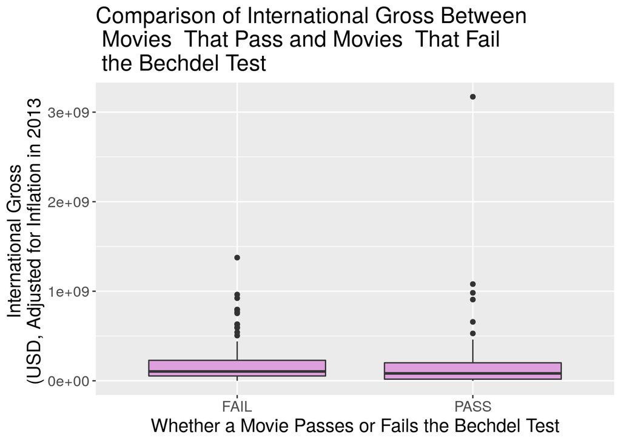

```r
ggplot(data = bechdelSampleNEW, aes(x = binary, y = intgross_2013)) +
  geom_boxplot(fill = "plum") + labs(title = "Comparison of International Gross Between \n Movies  That Pass and Movies  That Fail  \n the Bechdel Test", x = "Whether a Movie Passes or Fails the Bechdel Test", y = "International Gross \n (USD, Adjusted for Inflation in 2013  ") + theme(text = element_text(size = 15))
```

## ANALYSIS THREE

### Question: Do a higher proportion of movies with female directors pass the Bechdel Test than movies with male directors?

### Assumptions:

For this test we are assuming that the data comes from a random sample. We are also assuming that the conditions for statistical inference are met, but we are aware that, in actuality, our data set lacks the sufficient number of observations of movies with female directors (n = 30). Out of our data set of 200 movies, only 17 (8.5%) had female directors.

### Null and alternative hypotheses:

$H_0: p_{female} - p_{male} = 0$

$H_A: p_{female} - p_{male} > 0$

### Data visualization:

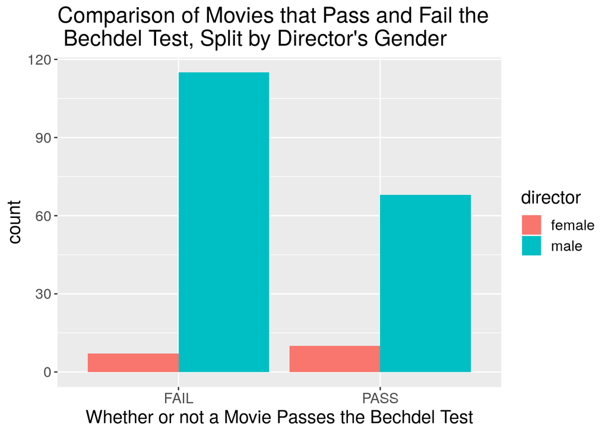

```r
ggplot(data = bechdelSampleNEW,  aes(x = binary, fill = director)) +
  geom_bar(position = "dodge") + labs (title = "Comparison of Movies that Pass and Fail the \n Bechdel Test, Split by Director's Gender", x = "Whether or not a Movie Passes the Bechdel Test") + theme(text = element_text(size = 15))
```

### Summary statistics

There were 17 female directors, or 8.5% of the movies in our sample had female directors. This statistic has a standard error of 0.0197 and margin of error of 0.0387. While 10 of 17 movies with female directors passed the test, only 68 of 183 movies with male directors passed. The difference in the proportion of female- and male- directed movies that passed the Bechdel Test is 0.217 with a p-value of 0.0401.

## ANALYSIS FOUR

### Assumptions:

In order to run this test we are working under the assumption that the data has a linear relationship, the residuals are normally distributed, there is no multicollinearity (none of the independent variables are highly correlated), and there is homoscedasticity, or equal variance, in the data.

### Null and alternative hypotheses

Testing Individual Predictors:

$\beta_i$ is the coefficient of predictor i

Testing Budget: $\beta_{budget}=0$ $\beta_{budget}\neq 0$

Testing IMDb Score: $\beta_{imdb}=0$ $\beta_{imdb}\neq 0$

Testing for a Binary Predictor Bechdel Test: $\beta_{pass}=0$ $\beta_{pass}\neq 0$

Testing for overall effectiveness of the model: $H_o$: Model is not effective $H_a$: Model is effective

### Summary statistics

```r
model_intgross2013 <- lm(intgross_2013 ~ binary + budget_2013 + imdb_1, data = bechdelSampleNEW)
```

```r
summary(model_intgross2013)
```

```
##
## Call:
## lm(formula = intgross_2013 ~ binary + budget_2013 + imdb_1, data = bechdelSampleNEW)
##
## Residuals:
##        Min         1Q     Median         3Q        Max
## -479410698  -77606219  -17318414   44571745 1982470433
##
## Coefficients:
##               Estimate Std. Error t value Pr(>|t|)
## (Intercept) -5.979e+08  1.227e+08  -4.875 2.25e-06 ***
## binaryPASS   8.228e+07  3.196e+07   2.574   0.0108 *
## budget_2013  3.701e+00  2.662e-01  13.906  < 2e-16 ***
## imdb_1       8.088e+07  1.779e+07   4.546 9.59e-06 ***
## ---
## Signif. codes:  0 '***' 0.001 '**' 0.01 '*' 0.05 '.' 0.1 ' ' 1
##
## Residual standard error: 216300000 on 195 degrees of freedom
##   (1 observation deleted due to missingness)
## Multiple R-squared:  0.5236, Adjusted R-squared:  0.5163
## F-statistic: 71.44 on 3 and 195 DF,  p-value: < 2.2e-16
```

# Results

## Analysis 1

```r
set.seed(42)

bechdelSampleNEW <- as.tbl(bechdelSampleNEW)

boot_samp_1000 <- bechdelSampleNEW %>%
  rep_sample_n(size = 200, reps = 1000, replace = TRUE)
```

```r
boot_distrib_budget <- boot_samp_1000 %>%
  group_by(replicate) %>%
  summarize(boot_stat = mean(budget_2013))
```

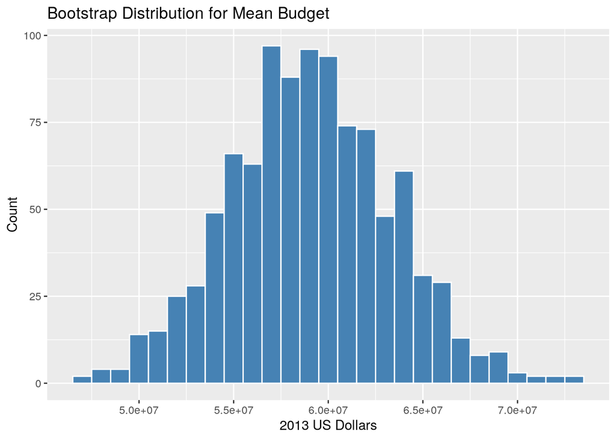

```r
ggplot(data = boot_distrib_budget, aes(x = boot_stat))+
  geom_histogram(binwidth = 1000000, color = "white", fill = "steelblue") +labs(title="Bootstrap Distribution for Mean Budget", x="2013 US Dollars", y="Count")
```

```r
boot_distrib_budget %>%
  summarize(mean = mean(boot_stat),
            se = sd(boot_stat),
            lower_ci = mean - (2 * se),
            upper_ci = mean + (2 * se))
```

```
## # A tibble: 1 x 4
##        mean       se  lower_ci  upper_ci
##       <dbl>    <dbl>     <dbl>     <dbl>
## 1 59053834. 4299876. 50454082. 67653587.
```

We concluded that we are 95% confident that the average budget for the movies in our sample which encompassed movies from 1990 and 2013 is between 50.45 and 67.65 million USD. While the original data prior to constructing the interval demonstrated a right skew, the bootstrap distribution was normally distributed which allowed us to continue to construct the aforementioned confidence interval of the mean budget.

## Analysis 2

```r
obs_diff_intgross_binary <- bechdelSampleNEW %>%
  specify(intgross_2013 ~ binary) %>%
  calculate(stat = "diff in means", order = c("PASS", "FAIL"))
obs_diff_intgross_binary
```

```
## # A tibble: 1 x 1
##       stat
##      <dbl>
## 1 2427075.
```

```r
set.seed(108)

intgross_in_null_world <- bechdelSampleNEW %>%
  specify(intgross_2013 ~ binary) %>%
  hypothesize(null = "independence") %>%
  generate(reps = 5000, type = "permute")
intgross_diff_under_null <- intgross_in_null_world %>%
  calculate(stat = "diff in means", order = c("PASS", "FAIL"))

intgross_diff_under_null %>%
  slice(1:5)
```

```
## # A tibble: 5 x 2
##   replicate       stat
##       <int>      <dbl>
## 1         1 -16272930.
## 2         2   6261057.
## 3         3  74864358.
## 4         4 -83881211.
## 5         5  11043249.
```

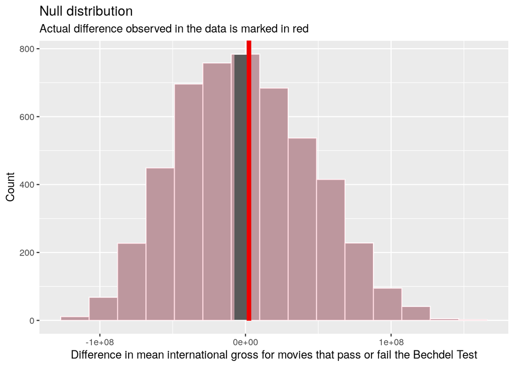

```r
visualize(intgross_diff_under_null) +
  shade_p_value(obs_stat = obs_diff_intgross_binary, direction = "both") +
  labs(x = "Difference in mean international gross for movies that pass or fail the Bechdel Test", y = "Count",
       title = "Null distribution",
      subtitle = "Actual difference observed in the data is marked in red")
```

```r
intgross_diff_under_null %>%
  get_pvalue(obs_stat = obs_diff_intgross_binary, direction = "greater")
```

```
## # A tibble: 1 x 1
##   p_value
##     <dbl>
## 1   0.459
```

## Analysis 3

```r
bechdelSampleNEW %>%
  summarize(n = n(),
            count_female = sum(director == "female"),
            p_hat =  count_female / n)
```

```
## # A tibble: 1 x 3
##       n count_female p_hat
##   <int>        <int> <dbl>
## 1   200           17 0.085
```

```r
bechdelSampleNEW <- bechdelSampleNEW %>%
  mutate(typcat =  recode_factor(director,
                                 "male " = "male",
                                 "male" = "male",
                                 " male" = "male",
                                 "female" = "female"))
```

```r
bechdelSampleNEW %>%
  summarize(n = n(),
            count_female = sum(director == "female"),
            p_hat =  count_female / n,
            se = sqrt(p_hat * (1 - p_hat) / n),
            me = qnorm(0.975) * se,
            lower_ci = p_hat - me,
            upper_ci = p_hat + me)
```

```
## # A tibble: 1 x 7
##       n count_female p_hat     se     me lower_ci upper_ci
##   <int>        <int> <dbl>  <dbl>  <dbl>    <dbl>    <dbl>
## 1   200           17 0.085 0.0197 0.0387   0.0463    0.124
```

$H_0: p_{female} - p_{male} = 0$

$H_A: p_{female} - p_{male} > 0$

```r
bechdelSampleNEW %>%
  group_by(director, binary) %>%
  summarize(count = n())
```

```
## # A tibble: 4 x 3
## # Groups:   director [2]
##   director binary count
##   <chr>    <chr>  <int>
## 1 female   FAIL       7
## 2 female   PASS      10
## 3 male     FAIL     115
## 4 male     PASS      68
```

```r
bechdelSampleNEW %>%
  specify(binary ~ director, success = "PASS") %>%
  calculate(stat = "diff in props", order = c( "female", "male"))
```

```
## # A tibble: 1 x 1
##    stat
##   <dbl>
## 1 0.217
```

```r
bechdelSampleNEW %>%
  specify(binary ~ director, success = "PASS") %>%
  calculate(stat = "z", order = c( "female", "male"))
```

```
## # A tibble: 1 x 1
##    stat
##   <dbl>
## 1  1.75
```

```r
1-pnorm(1.75)
```

```
## [1] 0.04005916
```

The difference in the proportion of movies with female directors that passed the bechdel test and movies with male directors that passed the Bechdel Test was 0.2167. Only 37.2% of the male-directed movies passed the Bechdel Test, whereas 58.8% of the female-directed movies passed the test.

## Analysis 4

```
## # A tibble: 4 x 7
##   term         estimate   std_error statistic p_value   lower_ci   upper_ci
##   <chr>           <dbl>       <dbl>     <dbl>   <dbl>      <dbl>      <dbl>
## 1 intercept     -5.98e8     1.23e+8     -4.88 0          -8.40e8    -3.56e8
## 2 binaryPA…      8.23e7     3.20e+7      2.57 0.0108      1.92e7     1.45e8
## 3 budget_2…      3.70e0     2.66e-1     13.9  0           3.18e0     4.23e0
## 4 imdb_1         8.09e7     1.78e+7      4.55 0.00001     4.58e7     1.16e8
```

```
##
## Call:
## lm(formula = intgross_2013 ~ binary + budget_2013 + imdb_1, data = bechdelSampleNEW)
##
## Residuals:
##        Min         1Q     Median         3Q        Max
## -479410698  -77606219  -17318414   44571745 1982470433
##
## Coefficients:
##               Estimate Std. Error t value Pr(>|t|)
## (Intercept) -5.979e+08  1.227e+08  -4.875 2.25e-06 ***
## binaryPASS   8.228e+07  3.196e+07   2.574   0.0108 *
## budget_2013  3.701e+00  2.662e-01  13.906  < 2e-16 ***
## imdb_1       8.088e+07  1.779e+07   4.546 9.59e-06 ***
## ---
## Signif. codes:  0 '***' 0.001 '**' 0.01 '*' 0.05 '.' 0.1 ' ' 1
##
## Residual standard error: 216300000 on 195 degrees of freedom
##   (1 observation deleted due to missingness)
## Multiple R-squared:  0.5236, Adjusted R-squared:  0.5163
## F-statistic: 71.44 on 3 and 195 DF,  p-value: < 2.2e-16
```

```
## Call:
##    aov(formula = model_intgross2013)
##
## Terms:
##                       binary  budget_2013       imdb_1    Residuals
## Sum of Squares  2.780763e+14 9.060369e+18 9.668715e+17 9.123954e+18
## Deg. of Freedom            1            1            1          195
##
## Residual standard error: 216308823
## Estimated effects may be unbalanced
## 1 observation deleted due to missingness
```

The coefficients for each predictor were positive, which meant that they positively impacted the predicted international gross. For every one point increase in IMDb score, the predicted international gross increases by 8.08E7 dollars, assuming budget and pass are kept constant. For every one dollar increase in budget, the predicted international gross increases by 3.7 dollars, assuming IMDb score and pass are kept constant. If a movie passes the Bechdel Test, the predicted international gross increases by 8.23E7 dollars, assuming budget and IMDb score are kept constant. The p values of all predictors were significant at the 5% level. Overall, our model was effective in predicting the success of a movie internationally. Given our R2 value, we can conclude that 52.36% of the variability in international gross income in USD is explained by the budget in USD, IMDb Score, and whether or not it passes the Bechdel Test.

# Discussion

## Implications

After using the confidence interval to gage where the mean budget for the movies in the fivethirtyeight sample could be we moved towards understanding the overall success of the films internationally and whether success depends on them passing the Bechdel Test. We used a difference in means hypothesis test to assess whether the mean international gross income of the films adjusted for 2013 USD differed for movies that passed the Bechdel Test and for movies that did not. After running our analysis, we calculated a p-value of 0.459 for the hypothesis test for a difference in means. At a 5% significance value, we failed to reject the null hypothesis that there was no difference in mean international gross between movies that pass the Bechdel Test and movies that fail. Therefore, we had no significant evidence to show that movies that pass the Bechdel test have a higher international gross. We were surprised by these results, as we expected movies that pass the Bechdel Test to be more successful than those that don’t. We think that this might not be the case because unfortunately movies and media in general tend to sexualize and stereotype women, given current societal norms. Movie directors and movie studies don’t prioritize portraying women in accurate ways, and stereotypical portrayals are easily digestible by the public. Movies like these tend to be more popular with the public, which may account for movies passing the Bechdel Test not having a higher international gross than those that fail.

[output not shown]

Once we assessed our results for the difference in proportions hypothesis test we moved on to assessing whether predictors passing the Bechdel Test, budget of the film in USD, and IMDb Score were good predictors of International gross income of a film in USD. Results from individual slope tests for the predictors in the model indicate that all predictors, passing the Bechdel Test, budget of the film in USD, and IMDb Score, are all significant at the 5% level. It was important to see that the Bechdel Test is quite significant in determining the overall international success of a movie in our model, which is once again only reflective of the fivethirtyeight dataset. We especially care that passing the Bechdel Test has a vast influence on the success of a film internationally. While not implying causality, our model demonstrated that when all other predictors are controlled for, passing the Bechdel Test increases the international success of a film by 82.3 million USD! This is important because it can be used as a piece of evidence towards convincing producers to produce films where women are not depicted in a blatantly biased way.  
Our model in its entirety was an effective model, as suggested by the p-value of 2.2(10-16) ≈ 0. Since the basis of our analysis is based on the collected data hosted on fivethirtyeight, the statistical tests by no means imply causation. Despite the fact that these analyses are just mere observations, it was surprising to see that our multiple regression model was effective and that our R2 value accounted for more than 50% of the variability, further indicating that the model accounts for the majority of the cases recorded in fivethirtyeight’s bechdel dataset.

## Limitations

The dataset we used was put together by fivethirtyeight. Their data was collected using two websites: BechdelTest.com and The-Numbers.com. The data on whether or not the movies passed the Bechdel Test was collected by moviegoers who analyze films and post their results on BechdelTest.com. The financial information for the films was found using The-Numbers.com, which inventories financial information for about 4,500 films. The movies present in the original fivethirtyeight dataset are the movies that had information available on both of these websites. Since this was an observational study, causality cannot be established. As the movies were not randomly selected, we cannot generalize to the entire population of popular Hollywood movies made between 1990 and 2013, but since we took a random sample of our original dataset we can generalize to the movies present in it.

One limitation in our analysis was in the proportion test. In our random sample of 200 cases, only 17 of them had female directors. For the CLT to apply, a sample of at least 30 is necessary, so our sample of 17 did not reach the minimum amount needed. However, in conducting the proportion test we assumed the CLT applied. As the variable “gender” was classified as categorical, we could not see if it was normally distributed. As we can not be sure if the CLT really applies to this test, we cannot generalize to the larger population as we cannot be sure that the mean of our sample will be approximately equal to that of the population.

### Checking Conditions:

```r
intgross_resid <- get_regression_points(model_intgross2013)
```

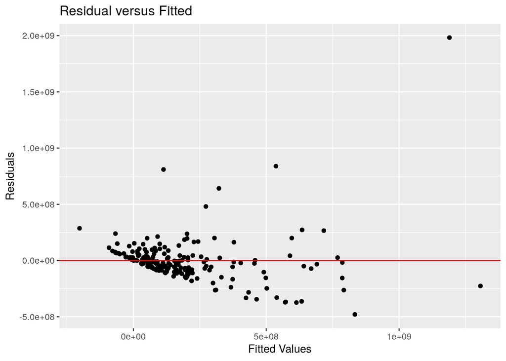

```r
ggplot(intgross_resid, aes(x = intgross_2013_hat, y = residual))+
  geom_point() +
  geom_abline(slope = 0, intercept = 0, color = "red") +
  labs(title = "Residual versus Fitted", x = "Fitted Values", y = "Residuals")
```

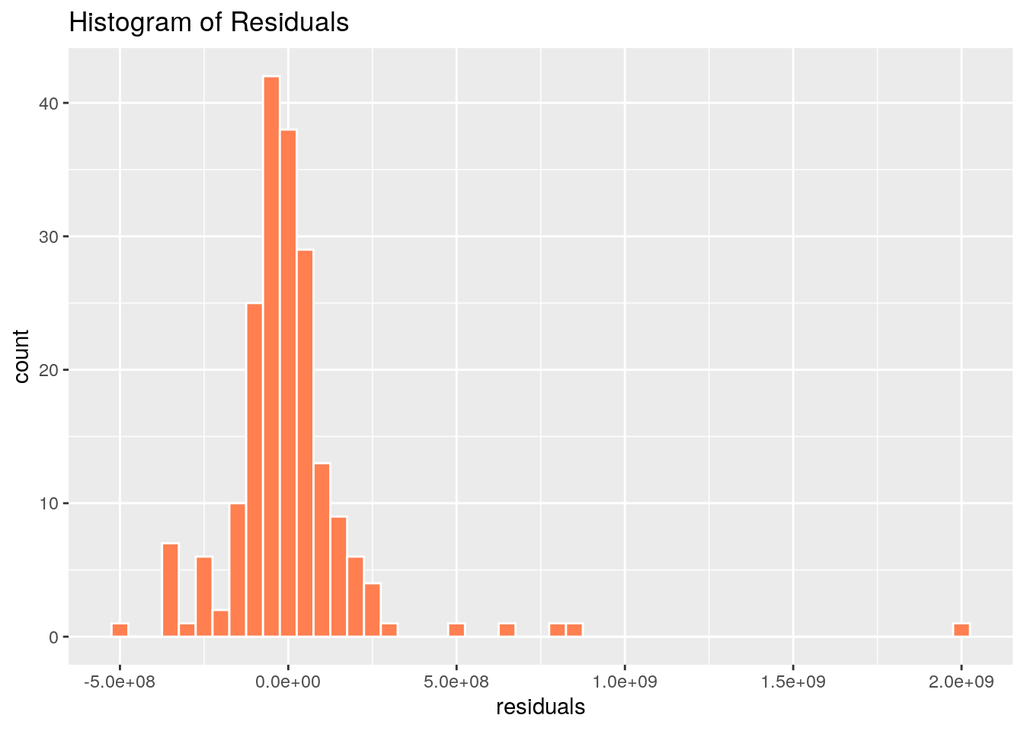

```r
 ggplot(intgross_resid, aes(x= residual)) +
 geom_histogram(binwidth = 50000000, fill = "coral", color = "white") +
 labs(x = "residuals") + labs(title = "Histogram of Residuals")
```

The Bechdel Test itself represents a limitation in understanding whether a movie portrays women in a way that is biased. The Bechdel Test does not take into account whether the conversation the two named women have enforces gender stereotypes, or in the case of movies like Gravity, which is dominated by Sandra Bullock, but she doesn’t speak to another woman. The Bechdel Test is not a model of whether the film is modeling gender equality, if women are integrated well into the film, or if the female characters are well written and play important parts in the plot. Though the Bechdel Test has many limitations, it is the best current test for gender equality in cinema. More criteria, such as the content of the conversation or screentime of women could be added to the Bechdel Test in the future.

# Conclusions

Through our statistical analysis of our 200-sample dataset, we found evidence that supports that idea that The Bechdel Test is a significant predictor of the financial success of a movie. We also found that there is a significant difference in the proportions of male-directed and female-directed movies that passed the Bechdel Test, with female-directed movies having a higher proportion of passing scores. The model we used for multiple regression was found to be effective at predicting the success of a movie based on their Bechdel Test result, budget, and IMDb score.

# Citations

[^1]: Hickey, Walt. “The Dollar-And-Cents Case Against Hollywood’s Exclusion of Women.” FiveThirtyEight, FiveThirtyEight, 1 Apr. 2014: